◎

**WEBGIS TESIS** Magister Geografi · Universitas Indonesia

# Pemodelan Pengaruh Fisik terhadap Dinamika Garis Pantai Kota Tegal Menggunakan DSAS, Random Forest dan CVI

Mengintegrasikan DSAS, *Coastal Vulnerability Index*, proksi neraca sedimen, *Random Forest*, dan evaluasi tata ruang pesisir.

**Rifqiya Luthfiyani** NPM. 2406372823

PEMBIMBING

Dr.Eng. Masita Dwi Mandini Manessa, S.Si., M.Si., M.Eng

Dr. Iwan Gunawan, M.Sc

STUDY AREA **Kota Tegal** Pantai Utara Jawa · Jawa Tengah

01 / LATAR BELAKANG

## Dinamika Pesisir Kota Tegal

Kota Tegal berada pada pesisir Pantura. Proses alam dan aktivitas manusia membentuk perubahan garis pantai yang berbeda antarsegmen.

STUDY AREA

Wilayah**Kota Tegal** Periode**1988–2025** Unit**46 transek**

01

### Pesisir Produktif

Permukiman, tambak, perikanan, pelabuhan, dan industri berkembang di dataran pesisir.

02

### Tekanan Pesisir

Abrasi, rob, perubahan sedimen, dan pemanfaatan ruang memengaruhi kondisi pantai.

03

### Respons Berbeda

Segmen natural dan segmen dengan intervensi manusia menunjukkan respons shoreline yang berbeda.

04

### Kebutuhan Analisis

Perubahan historis perlu dihubungkan dengan kerentanan, sedimen, prediksi, dan tata ruang.

**Proses fisik***+***Intervensi manusia***→***Dinamika shoreline**

02 / CELAH PENELITIAN

## Analisis pesisir masih banyak dilakukan secara terpisah

KAJIAN TERDAHULU

### Historis dan sektoral

Perubahan garis pantai, kerentanan, sedimen, dan prediksi sering dianalisis sebagai komponen terpisah.

→

PENELITIAN INI

### Spasial-temporal terintegrasi

DSAS, CVI, proksi sedimen, Random Forest, dan tata ruang dihubungkan dalam satu kerangka analisis.

POSISI PENELITIAN **Kebaruan penelitian terletak pada integrasi rekonstruksi historis, kerentanan, konteks proses sedimen, pemodelan prediktif, dan evaluasi tata ruang.**

03 / BATASAN PENELITIAN

## Ruang Lingkup Analisis

01WILAYAH

### Pesisir Kota Tegal

02PERIODE

### 1988–2025

03UNIT ANALISIS

### 46 transek

04DINAMIKA

### DSAS

LRR · EPR · NSM · SCE

05KERENTANAN

### 8 parameter CVI

06PROSES

### Proksi sedimen

TSS · Hs · MWP · MWD · Δ shoreline · muara

07PREDIKSI

### Random Forest

Proyeksi posisi garis pantai 2035

08TIPOLOGI

### Natural & buatan

Pemisahan respons pantai terhadap intervensi

04 / PERTANYAAN PENELITIAN

## Tiga pertanyaan penelitian

RQ 01

### Bagaimana bentuk pola spasial pengaruh Indeks Kerentanan Pesisir (*Coastal Vulnerability Index*/CVI) terhadap dinamika perubahan garis pantai di wilayah pesisir Kota Tegal?

Fokus: keterkaitan pola kerentanan pesisir dengan dinamika garis pantai serta variasinya pada segmen natural dan buatan.

RQ 02

### Bagaimana prediksi posisi garis pantai Kota Tegal dalam 10 tahun mendatang berkaitan dengan pola perubahan fisik yang terjadi menggunakan algoritma *Random Forest*?

Fokus: prediksi posisi garis pantai hingga 2035 berdasarkan pola perubahan fisik pada segmen natural dan buatan.

RQ 03

### Bagaimana keterkaitan hasil analisis kerentanan pesisir dan prediksi perubahan garis pantai dengan RDTR di wilayah pesisir Kota Tegal?

Fokus: membandingkan kerentanan dan prediksi perubahan garis pantai dengan arahan pemanfaatan ruang dalam RDTR pesisir Kota Tegal.

05 / METODE PENELITIAN

## Alur Penelitian

Penelitian dilaksanakan dari pengumpulan dan pengolahan data multitemporal hingga analisis dinamika, kerentanan, proksi sedimen, prediksi garis pantai, dan evaluasi tata ruang.

→

→

→

→

→

→

**01 · Pengumpulan Data**

Landsat 5/7/8/9 , DEMNAS, ERA5, INATides, data kenaikan muka laut, tutupan lahan, TSS, muara sungai, struktur pantai, dan RDTR Kota Tegal.

**02 · Pra-pemrosesan**

Citra diseleksi pada musim kering, dilakukan masking awan, komposit median, ekstraksi badan air menggunakan indeks air dan threshold Otsu, kemudian dibentuk shoreline multitemporal 1988–2025.

Landsat**→**Masking**→**Komposit**→**Indeks air + Otsu**→**Shoreline

**03 · Digital Shoreline Analysis System (DSAS)**

Dinamika garis pantai dianalisis pada transek berjarak 200 m. LRR digunakan sebagai metrik utama, sedangkan EPR, NSM, dan SCE digunakan untuk membaca besar serta konsistensi perubahan.

Baseline**→**Transek 200 m**→**LRREPRNSMSCE

**04 · Coastal Vulnerability Index (CVI)**

Delapan parameter diberi skor 1–5. Skor 1 menunjukkan kerentanan sangat rendah dan skor 5 menunjukkan kerentanan sangat tinggi.

ShorelineGeomorfologiSlopeElevasiGelombangSLRPasang SurutTutupan Lahan

KLASIFIKASI PARAMETER

#### Skoring Coastal Vulnerability Index

| Parameter | 1 · Sangat Rendah | 2 · Rendah | 3 · Sedang | 4 · Tinggi | 5 · Sangat Tinggi |
| --- | --- | --- | --- | --- | --- |
| **Shoreline (m/tahun)** | ≥ 2,0 Akresi tinggi | 1,0–2,0 | −1,0–1,0 Stabil | −1,1–−2,0 | ≤ −2,0 Abrasi tinggi |
| **Geomorfologi** | Tebing batuan / rocky coast | Pantai pasir kasar | Pantai pasir halus | Dataran aluvial / estuari | Rawa, mangrove, tambak, mudflat |
| **Slope (%)** | > 12 | 8–12 | 4–8 | 2–4 | < 2 |
| **Elevasi (m)** | > 30,1 | 20,1–30,0 | 10,1–20,0 | 5,1–10,0 | 0–5,0 |
| **Hs rata-rata (m)** | < 0,245 | 0,245–0,258 | 0,258–0,268 | 0,268–0,275 | > 0,275 |
| **SLR (mm/tahun)** | < −1,21 | −1,21–0,1 | 0,1–1,24 | 1,24–1,36 | > 1,36 |
| **Pasang surut (m)** | > 0,921 | 0,884–0,921 | 0,873–0,884 | 0,837–0,873 | < 0,837 |
| **Tutupan lahan** | Mangrove | Pantai | Tambak campuran | Muara / lahan terbuka dinamis | Bangunan / pelabuhan / kawasan terbangun padat |

Skoring mengacu pada klasifikasi yang digunakan dalam tesis: Gornitz (1991), Thieler & Hammar-Klose (2000), serta Abuodha/Aboudha.

**05 · Proksi Neraca Sedimen**

Proksi digunakan untuk membaca kecenderungan relatif surplus–defisit, bukan menghitung neraca sedimen absolut. Interpretasi utama menggabungkan respons shoreline dengan TSS terhadap ambang lokal 30,4 mg/L, jarak muara serta Hs, MWD, dan MWP digunakan untuk menjelaskan sumber dan redistribusi sedimen.

Muara  
Sumber**+**TSS  
Ketersediaan**+**Hs · MWD · MWP  
Redistribusi**+**Δ Shoreline  
Respons**→**Proksi Sedimen

ATURAN KLASIFIKASI

#### Lima kelas proksi neraca sedimen

| Respons shoreline | Status TSS | Kelas proksi | Interpretasi |
| --- | --- | --- | --- |
| **Akresi** | ≥ 30,4 mg/L | Surplus / Deposisi | Sedimen tersuspensi melimpah dan terakumulasi pada segmen. |
| **Akresi** | < 30,4 mg/L | Deposisi Lokal | Pantai tetap maju meskipun TSS rendah; dapat mencerminkan material dasar yang tidak terekam TSS optik. |
| **Stabil** | Tidak menentukan | Relatif Seimbang | Masukan dan keluaran sedimen diinterpretasikan relatif setara. |
| **Abrasi** | ≥ 30,4 mg/L | Bypass / Export | Material tersedia, tetapi tidak terakumulasi dan cenderung ditransportasikan ke segmen lain. |
| **Abrasi** | < 30,4 mg/L | Defisit / Erosi | Ketersediaan material rendah disertai kemunduran shoreline. |

**Ambang TSS 30,4 mg/L** = median seluruh data TSS tahunan pada 46 transek periode 1988–2025 (n = 1.683). Kelas merupakan interpretasi proksi proses sedimen, bukan volume atau massa sedimen absolut.

**06 · Random Forest**

Model dibangun terpisah untuk segmen natural dan buatan, kemudian hasil prediksi direkonstruksi menjadi satu garis pantai 2035. Evaluasi model menggunakan R², MAE, dan RMSE.

DSAS**+**CVI**+**Variabel fisik & sedimen**→**RF Natural / Buatan**→**R² · MAE · RMSE**→**Shoreline 2035

**07 · Evaluasi Tata Ruang (RDTR)**

Hasil kerentanan pesisir dan prediksi garis pantai 2035 dioverlay dengan RDTR untuk mengidentifikasi keterkaitan dan spatial mismatch pada kawasan pesisir Kota Tegal.

CVI**+**Prediksi 2035**+**RDTR**→**Overlay**→**Spatial Mismatch

**Kerangka utama**Data → Pra-pemrosesan → DSAS → CVI → Proksi Sedimen → Random Forest → RDTR

06 / HASIL & PEMBAHASAN DINAMIKA GARIS PANTAI

## Dinamika Garis Pantai 1988–2025

Hasil DSAS dibaca terpisah antara segmen **natural** dan **buatan** agar respons perubahan garis pantai terhadap kondisi alami dan intervensi manusia dapat dibandingkan.

PERIODE ANALISIS**37 tahun**1988 → 2025

**PETA INTERAKTIF DSAS**

INFORMASI SEGMEN**Semua Segmen**

Abrasi Tinggi Abrasi Sedang Stabil Akresi Sedang Akresi Tinggi

HASIL

### Natural vs Buatan

LRR RATA-RATA **−0,96 m/tahun**

Tren garis pantai mundur.

POLA DOMINAN **69,57% Abrasi** 32 dari 46 transek

Abrasi mendominasi.

KESIMPULAN

Secara umum pesisir Kota Tegal mengalami kemunduran, dengan abrasi pada 69,57% transek.

06 / HASIL & PEMBAHASAN KERENTANAN PESISIR (CVI)

## Kerentanan Pesisir: Natural vs Buatan

Kerentanan dibaca terpisah pada segmen **natural** dan **buatan**, kemudian dibandingkan menurut **tipologi geomorfologi**. Natural terdiri atas Pasir Halus, Tambak, dan Aluvial; Buatan terdiri atas Bebatuan, Pasir Kasar, Pasir Halus, Tambak, dan Aluvial.

PARAMETER CVI**8**skor 1 → 5

**CVI SEMUA SEGMEN · SHORELINE**

INFORMASI CVI**Semua Segmen**

Akresi TinggiAkresi SedangStabilAbrasi SedangAbrasi Tinggi

HASIL ANALISA

### Shoreline · Semua Segmen

KESIMPULAN SINGKAT

JAWABAN PERTANYAAN PENELITIAN 1

### Pola Spasial CVI terhadap Dinamika Garis Pantai

**Pola spasial CVI dan dinamika garis pantai Kota Tegal berbeda antara segmen natural dan buatan.** Segmen natural memiliki kerentanan lebih tinggi (CVI rata-rata 44,4) dan abrasi lebih konsisten, dengan LRR rata-rata −2,38 m/tahun serta 12 dari 13 transek (92,3%) mengalami kemunduran. Segmen buatan memiliki CVI rata-rata lebih rendah (30,4) dan laju kemunduran lebih kecil, dengan LRR rata-rata −0,38 m/tahun, tetapi 20 dari 33 transek masih mengalami abrasi. Artinya, kerentanan yang tinggi cenderung berasosiasi dengan kemunduran garis pantai yang lebih kuat pada segmen natural, sedangkan pada segmen buatan responsnya lebih heterogen karena dipengaruhi intervensi pantai. Dengan demikian, hubungan CVI–dinamika garis pantai bersifat spasial dan perlu dibaca bersama tipologi geomorfologi serta status intervensi setiap segmen.

**Inti pembahasan CVI**Parameter fisik → skor kerentanan → pola spasial natural–buatan → keterkaitan dengan dinamika garis pantai.

06 / HASIL & PEMBAHASAN · 03PROKSI NERACA SEDIMEN · 1988–2025

## Proksi Neraca Sedimen

Membaca kecenderungan relatif deposisi–defisit melalui TSS, karakter gelombang, perubahan shoreline, kedekatan muara, dan pembagian sel sedimen. Hasil merupakan proksi proses, bukan neraca sedimen absolut.

DATA SPASIAL**3 layer**Natural · Buatan · Sel

Tahun

**PETA TITIK PROKSI SEDIMEN 1988–2025**SEDIMEN_NATURAL · SEDIMEN_BUATAN · PEMBAGIAN_SEL

**Semua Tahun**— titik

Surplus/DeposisiDeposisi LokalRelatif SeimbangBypass/ExportDefisit/Erosi

HASIL ANALISA

### Semua Segmen

KESIMPULAN SINGKAT

Pilih segmen untuk membaca kecenderungan proksi sedimen.

ARAH POTENSIAL TRANSPOR SEDIMEN

### Arah Dominan Proksi Sedimen per Periode

Gambar merangkum kelas proksi yang paling sering muncul per transek dan arah bersih potensial transpor sejajar pantai untuk tiga periode: **1988–2000**, **2001–2012**, dan **2013–2025**. Panah menunjukkan **arah potensial** berdasarkan arah datang gelombang terhadap orientasi garis pantai, bukan hasil pengukuran arus atau volume transpor sedimen.

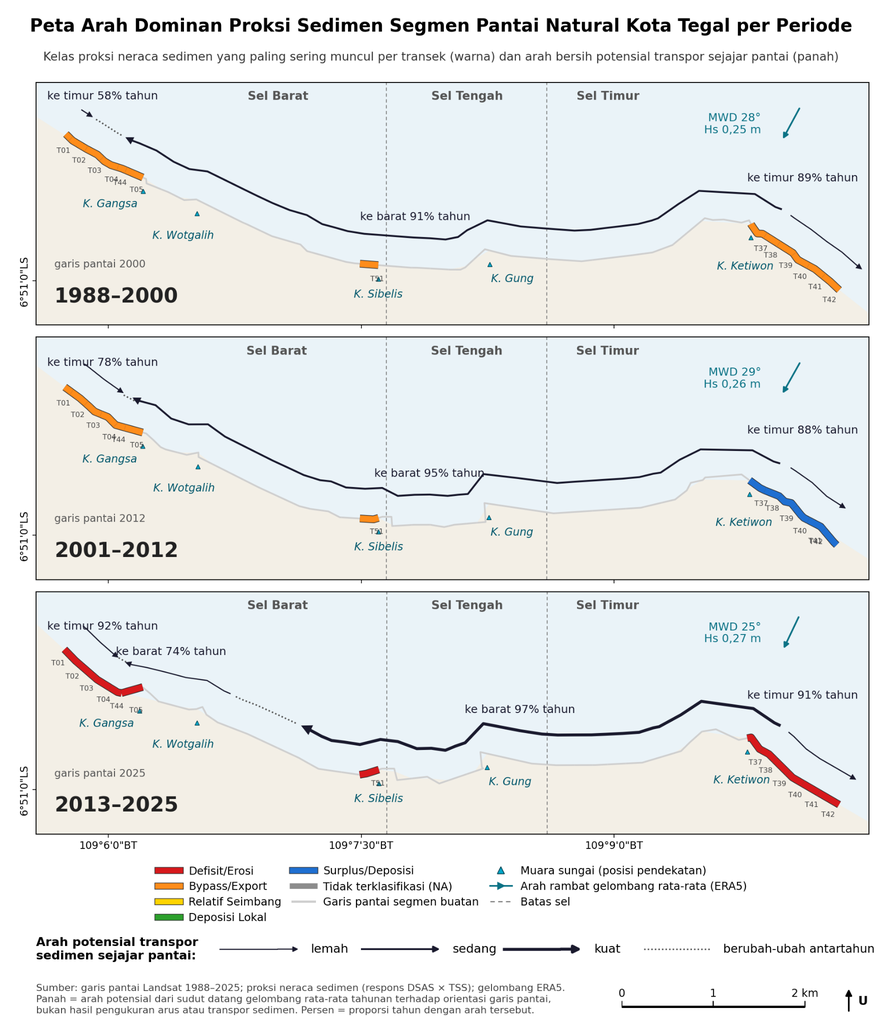

**Segmen Natural.** Ringkasan spasial-temporal kelas proksi dan kecenderungan arah potensial transpor sedimen sepanjang pantai pada tiga periode analisis.

06 / HASIL & PEMBAHASAN · 04RANDOM FOREST · PREDIKSI 2035

## Prediksi Garis Pantai 2035

Prediksi Random Forest dianalisis terpisah untuk segmen natural dan buatan, kemudian ditampilkan kembali dalam satu garis prediksi untuk membandingkan posisi 2035 terhadap baseline 2025.

HORIZON**10 tahun**2025 → 2035

**PETA PREDIKSI RF**GARIS_RF_2035 + baseline 2025

**Prediksi 2035**

Baseline 2025 NaturalBaseline 2025 Buatan2035 Natural2035 Buatan

KESIMPULAN SINGKAT

HASIL PREDIKSI

### Natural vs Buatan

NATURAL**−23,83 m**rata-rata perubahan 2025–2035

*Tipologi: Pasir Halus · Tambak · Aluvial*

BUATAN**−3,78 m**rata-rata perubahan 2025–2035

20 dari 33 transek mundur dan 13 maju.  
**Kemunduran terbesar:** T36, −49,30 m · **Pasir Halus**.  
**Kemajuan terbesar:** T45, +27,00 m · **Aluvial**.

*Tipologi: Bebatuan · Pasir Kasar · Pasir Halus · Tambak · Aluvial*

EVALUASI MODEL · TABEL 7 TESIS

### Kinerja Random Forest berdasarkan Skema Validasi

Uji temporal 2016–2025 dan validasi silang per transek dibedakan agar hasil kecocokan model tidak disamakan dengan kemampuan prediksi pada transek yang tidak ikut dilatih.

| Segmen dan Skema Validasi | Jumlah Transek | Rentang LRR Aktual | R² | MAE (m/tahun) | RMSE (m/tahun) |
| --- | --- | --- | --- | --- | --- |
| **Natural**Uji temporal 2016–2025 | 13 | −4,54 s.d. +0,72 m/tahun | **1,000** | 0,001 | 0,001 |
| **Natural**Validasi silang per transek | 13 | −4,54 s.d. +0,72 m/tahun | **0,15** | **1,02** | **1,25** |
| **Buatan**Uji temporal 2016–2025 | 33 | −4,93 s.d. +2,70 m/tahun | **1,000** | <0,001 | 0,002 |
| **Buatan**Validasi silang per transek | 33 | −4,93 s.d. +2,70 m/tahun | **−0,23** | **1,45** | **2,11** |

**Interpretasi sesuai Bab 5.2.4 tesis:** Nilai R² 1,000 pada uji temporal terutama mencerminkan pengenalan transek yang sama dalam data latih dan uji, bukan kemampuan prediksi pada lokasi baru. Validasi silang per transek menghasilkan R² 0,15 (natural) dan −0,23 (buatan). Dengan demikian, proyeksi posisi garis pantai 2035 merupakan kelanjutan tren historis setiap transek dengan asumsi kondisi fisik dan struktur pantai tetap seperti pada 2025.

DATA PREDIKSI TERBARU · 2035

### Perubahan garis pantai tiap transek

Nilai dalam meter dari PERUBAHAN_2025_2035. Nilai negatif berarti mundur; positif berarti maju. Gunakan pencarian untuk melihat transek tertentu.

Cari transek Jenis segmen

[output not shown]

Angka dihitung/ditampilkan dari dua file PREDIKSI_RF_NATURAL_2035 dan PREDIKSI_RF_BUATAN_2035; hasil jarak diukur menurut transek dan titik acuan asli. Data tabel tersedia tanpa GeoJSON.

FEATURE IMPORTANCE

### Faktor dominan model Random Forest

Persentase diperbarui dari FEATURE_IMPORTANCE_RF_NATURAL_TESIS dan FEATURE_IMPORTANCE_RF_BUATAN_TESIS yang baru diunggah.

**Interpretasi:** Pada segmen natural, Jarak Muara (35,03%), Elevasi (28,65%), dan Kemiringan Lereng (27,34%) menjadi tiga prediktor teratas. Pada segmen buatan, Elevasi (36,76%), Jarak Muara (32,54%), dan Kemiringan Lereng (20,94%) mendominasi. Angka merupakan kontribusi relatif pada model, bukan bukti hubungan sebab-akibat.

JAWABAN PERTANYAAN PENELITIAN 2

### Prediksi Posisi Garis Pantai Tahun 2035

Hasil pemodelan *Random Forest* menunjukkan pola perubahan garis pantai Kota Tegal yang berbeda antara segmen natural dan buatan. Dari 46 transek, sebanyak **32 transek diprediksi mundur dan 14 transek maju**. Pada segmen natural, 12 dari 13 transek diprediksi mengalami kemunduran dengan rata-rata perubahan **−23,83 m**, sedangkan pada segmen buatan 20 dari 33 transek diprediksi mundur dengan rata-rata perubahan **−3,78 m**. Kemunduran terbesar diproyeksikan pada T36 (−49,30 m) dan T37 (−45,38 m), sedangkan kemajuan terbesar terjadi pada T45 (+27,00 m).

Hasil *feature importance* menunjukkan bahwa model segmen natural terutama menggunakan jarak muara (35,03%), elevasi (28,65%), dan kemiringan lereng (27,34%). Pada segmen buatan, kontribusi tertinggi berasal dari elevasi (36,76%), jarak muara (32,54%), dan kemiringan lereng (20,94%). Nilai tersebut menunjukkan kontribusi relatif prediktor dalam model, bukan membuktikan hubungan sebab-akibat.

Walaupun evaluasi temporal menghasilkan R² yang sangat tinggi, **validasi silang per transek hanya menghasilkan R² 0,15 untuk natural dan −0,23 untuk buatan**. Dengan demikian, posisi garis pantai 2035 merupakan **skenario indikatif yang mengikuti pola historis** untuk mengidentifikasi lokasi prioritas, bukan posisi garis pantai yang pasti pada masa mendatang.

HASIL & PEMBAHASAN 05RDTR KOTA TEGAL 2023–2043 · PREDIKSI 2035

## Analisis Gap dan Evaluasi Tata Ruang

Perbandingan perubahan garis pantai, kerentanan, dan prediksi 2035 dengan pola ruang RDTR Kota Tegal (Perwali No. 17 Tahun 2023).

CAKUPAN**35 segmen**di dalam RDTR

AREA EVALUASI 300 M**217,72 ha**117,41 ha lindung · 100,31 ha budidaya

LAHAN BERPOTENSI MUNDUR**9,86 ha**7,92 ha berada di dalam RDTR

LAHAN BERPOTENSI MAJU**5,65 ha**Akresi terutama di bagian timur

**PETA PERUBAHAN LAHAN & ARAHAN TATA RUANG**RDTR 2023–2043 · Garis pantai 2025 dan proyeksi 2035

Tata ruang pesisir Perubahan lahan Kelas arahan Garis pantai 2025 Prediksi 2035

Mundur Maju Tata ruang Garis 2025 Garis 2035

Klik poligon perubahan untuk melihat **zona dan luas (ha)**. Klik arahan untuk melihat kelas kesesuaian, alasan, dan rekomendasi per segmen. Angka menggunakan atribut GeoJSON, bukan perhitungan ulang di browser.

SelarasPerlu penyesuaianTidak selaras

KESELARASAN POLA RUANG

### 35 segmen pesisir RDTR

**12**Selaras · 34,3%

**15**Perlu penyesuaian · 42,9%

**8**Tidak selaras · 22,9%

Tidak selaras terutama pada T44–T05, T07–T11, T16–T18, dan T35–T36, ketika kemunduran berhadapan dengan perumahan atau pariwisata. Pelabuhan dan perikanan T19–T23 membutuhkan penyesuaian perlindungan karena bergantung pada akses laut.

01 · PERUBAHAN LAHAN

### Kontras barat dan timur

Sekitar 7,23 ha (73%) lahan mundur berada di bagian barat, sedangkan sekitar 4,28 ha (76%) lahan maju berada di bagian timur. Dari 7,92 ha lahan mundur dalam RDTR, 7,19 ha berupa RTH Taman Kota.

02 · SEMPADAN PANTAI

### Perlindungan belum merata

Baru 57,2% dari jalur RDTR 100 m ke arah darat dari garis prediksi 2035 tercakup ketentuan sempadan. Kesenjangan tampak di ujung barat dan kawasan pelabuhan.

03 · ARAHAN ZONASI

### Penanganan per segmen

Batasi bangunan permanen baru di segmen tidak selaras, perkuat perlindungan pelabuhan, dan tetapkan status serta fungsi lahan timbul sebelum dimanfaatkan.

JAWABAN PERTANYAAN PENELITIAN 3

### Keterkaitan Dinamika Garis Pantai dengan Tata Ruang Pesisir Kota Tegal

Hasil evaluasi terhadap RDTR Kota Tegal 2023–2043 menunjukkan bahwa kesesuaian pemanfaatan ruang pesisir dengan prediksi perubahan garis pantai tahun 2035 berbeda antarsegmen. Dari **35 segmen yang dievaluasi**, sebanyak **12 segmen (34,3%) selaras**, **15 segmen (42,9%) memerlukan penyesuaian**, dan **8 segmen (22,9%) tidak selaras**.

Prediksi perubahan garis pantai menghasilkan potensi kehilangan daratan seluas **9,86 ha** dan penambahan daratan seluas **5,65 ha**. Kemunduran terutama terjadi di bagian barat dengan luas sekitar **7,23 ha**, sedangkan penambahan daratan lebih dominan di bagian timur dengan luas sekitar **4,28 ha**. Dari 9,86 ha lahan yang berpotensi mengalami kemunduran, sekitar **7,92 ha** berada dalam cakupan RDTR, terutama pada zona RTH Taman Kota.

Ketidaksesuaian tata ruang ditemukan antara lain pada kelompok segmen **T44–T05, T07–T11, T16–T18, dan T35–T36**, yang memerlukan perhatian terhadap pemanfaatan ruang di kawasan dengan potensi kemunduran garis pantai. Kawasan pelabuhan dan perikanan pada **T19–T23** memerlukan pendekatan perlindungan sesuai fungsi kawasan, sedangkan lahan yang berpotensi terbentuk akibat akresi membutuhkan pengaturan pemanfaatan sebelum dikembangkan.

Dengan demikian, **evaluasi RDTR perlu dilakukan secara spesifik menurut karakteristik dan dinamika setiap segmen pantai**, melalui pengendalian pemanfaatan ruang pada kawasan berpotensi abrasi, penyesuaian perlindungan kawasan terbangun, serta pengaturan lahan timbul pada kawasan akresi. Hasil prediksi 2035 digunakan sebagai **dasar evaluasi indikatif**, bukan sebagai penetapan batas garis pantai atau zonasi yang baru.

BAB VI · SINTESIS

## Kesimpulan dan Saran

Sintesis temuan penelitian periode 1988–2025, skenario garis pantai 2035, dan implikasinya bagi tata ruang pesisir Kota Tegal.

01 · DINAMIKA, KERENTANAN, DAN PROKSI SEDIMEN

### Kerentanan fisik berkaitan dengan pola perubahan garis pantai

Selama 1988–2025, 12 dari 13 transek natural (92,3%) mengalami kemunduran dengan rata-rata LRR −2,38 m/tahun, sedangkan 33 transek buatan menunjukkan perubahan yang lebih bervariasi dengan rata-rata LRR −0,38 m/tahun. Kemunduran kuat terjadi di T36 dan Pantai Alam Indah (T37), sementara kemajuan terkonsentrasi di bagian timur kawasan pelabuhan (T24–T30 dan T45). Secara spasial, transek dengan kerentanan fisik lebih tinggi cenderung mengalami kemunduran garis pantai lebih besar; perbedaannya berkaitan dengan geomorfologi, kemiringan lereng, tutupan lahan, serta kondisi segmen natural dan buatan. Proksi sedimen memperlihatkan pergeseran indikasi menuju defisit/erosi dan deposisi lokal pada periode akhir, tetapi tetap merupakan indikator relatif, bukan pengukuran langsung neraca sedimen. Dengan demikian, hasil CVI membantu mengidentifikasi segmen pantai yang memerlukan perhatian terhadap abrasi dan pengelolaan sesuai karakter fisiknya, bukan membuktikan hubungan sebab-akibat.

02 · PREDIKSI RANDOM FOREST 2035

### 32 transek diprediksi mundur dan 14 maju

Prediksi 2035 menunjukkan 32 dari 46 transek mundur dan 14 maju, dengan kemunduran terbesar pada T36 (−49,30 m) dan T37 (−45,38 m), sedangkan kemajuan terbesar pada T45 (+27,00 m). Validasi silang per transek menghasilkan R² 0,15 untuk natural dan −0,23 untuk buatan. Oleh karena itu, prediksi digunakan sebagai skenario indikatif kelanjutan tren historis, bukan posisi pasti garis pantai pada 2035.

03 · EVALUASI RDTR 2023–2043

### Penyesuaian tata ruang perlu mengikuti karakter segmen

Evaluasi 35 segmen pesisir dalam RDTR menunjukkan 12 segmen selaras (34,3%), 15 perlu penyesuaian (42,9%), dan 8 tidak selaras (22,9%). Potensi lahan mundur mencapai 9,86 ha dan lahan maju 5,65 ha. Penanganan perlu dibedakan menurut kawasan abrasi dan ruang terbangun, fungsi pelabuhan/perikanan, serta lahan timbul akibat akresi. Hasil prediksi 2035 merupakan dasar evaluasi indikatif, bukan perubahan batas zonasi secara otomatis.

SINTESIS SPASIAL

**Pesisir Kota Tegal tidak berubah secara seragam.** Bagian barat cenderung mundur, bagian timur kawasan pelabuhan cenderung maju, dan ujung timur di Pantai Alam Indah kembali mundur. Perbedaan tersebut berkaitan dengan posisi terhadap muara, topografi, geomorfologi, dan intervensi struktur pantai. Karena itu, pengelolaan dan penyesuaian tata ruang perlu mengikuti karakter setiap segmen.

### Saran Pengelolaan dan Penelitian Lanjutan

#### Pengelolaan Pesisir dan Tata Ruang

Lakukan pemantauan garis pantai berkala, terutama pada segmen abrasi konsisten dan segmen yang tidak selaras dengan RDTR. Pertahankan ruang terbuka, vegetasi, dan fungsi lindung pada pantai natural; evaluasi efektivitas revetment, jetty, groin, dan breakwater pada pantai buatan.

Prioritaskan pengendalian bangunan permanen baru dan peninjauan pengaturan sempadan di T44–T05, T07–T11, T16–T18, dan T35–T36. Pertahankan fungsi pelabuhan/perikanan T19–T23 melalui perlindungan sesuai kebutuhan akses laut. Tetapkan status dan peruntukan lahan timbul sebelum pemanfaatan terbangun, khususnya pada segmen akresi di sekitar T24–T45 dan T30–T32.

#### Penelitian Lanjutan

Validasi proksi sedimen melalui pengukuran debit sedimen, granulometri, batimetri multitemporal, dan transpor sedimen; harmonisasi estimasi TSS antar-generasi Landsat. Tambahkan riwayat pembangunan struktur pantai, subsidensi, dan perubahan penggunaan lahan pada pemodelan, serta uji skenario pembangunan struktur baru, termasuk Giant Sea Wall.

Gunakan validasi silang per transek atau per lokasi dan bandingkan kontribusi variabel dengan *permutation importance*. Uji kembali prediksi 2035 melalui pemantauan berkala serta bandingkan temuan dengan wilayah Pantura lain.